# Risk Factor Analysis

## Outcome Variable

**Outcome Variable:** ever_wasted

## Predictor Variables

**Intervention Variable:** parity

**Adjustment Set:**

unadjusted

## Stratifying Variables

The analysis was stratified on these variable(s):

- agecat
- studyid
- country

## Data Summary

| agecat | studyid | country | parity | ever_wasted | n_cell | n |
| --- | --- | --- | --- | --- | --- | --- |
| 0-24 months | ki1000304b-SAS-CompFeed | INDIA | 1 | 0 | 273 | 1513 |
| 0-24 months | ki1000304b-SAS-CompFeed | INDIA | 1 | 1 | 175 | 1513 |
| 0-24 months | ki1000304b-SAS-CompFeed | INDIA | 2 | 0 | 219 | 1513 |
| 0-24 months | ki1000304b-SAS-CompFeed | INDIA | 2 | 1 | 135 | 1513 |
| 0-24 months | ki1000304b-SAS-CompFeed | INDIA | 3+ | 0 | 393 | 1513 |
| 0-24 months | ki1000304b-SAS-CompFeed | INDIA | 3+ | 1 | 318 | 1513 |
| 0-24 months | ki1000304b-SAS-FoodSuppl | INDIA | 1 | 0 | 51 | 397 |
| 0-24 months | ki1000304b-SAS-FoodSuppl | INDIA | 1 | 1 | 26 | 397 |
| 0-24 months | ki1000304b-SAS-FoodSuppl | INDIA | 2 | 0 | 46 | 397 |
| 0-24 months | ki1000304b-SAS-FoodSuppl | INDIA | 2 | 1 | 46 | 397 |
| 0-24 months | ki1000304b-SAS-FoodSuppl | INDIA | 3+ | 0 | 112 | 397 |
| 0-24 months | ki1000304b-SAS-FoodSuppl | INDIA | 3+ | 1 | 116 | 397 |
| 0-24 months | ki1017093b-PROVIDE | BANGLADESH | 1 | 0 | 163 | 700 |
| 0-24 months | ki1017093b-PROVIDE | BANGLADESH | 1 | 1 | 108 | 700 |
| 0-24 months | ki1017093b-PROVIDE | BANGLADESH | 2 | 0 | 170 | 700 |
| 0-24 months | ki1017093b-PROVIDE | BANGLADESH | 2 | 1 | 74 | 700 |
| 0-24 months | ki1017093b-PROVIDE | BANGLADESH | 3+ | 0 | 121 | 700 |
| 0-24 months | ki1017093b-PROVIDE | BANGLADESH | 3+ | 1 | 64 | 700 |
| 0-24 months | ki1066203-TanzaniaChild2 | TANZANIA, UNITED REPUBLIC OF | 1 | 0 | 624 | 2357 |
| 0-24 months | ki1066203-TanzaniaChild2 | TANZANIA, UNITED REPUBLIC OF | 1 | 1 | 197 | 2357 |
| 0-24 months | ki1066203-TanzaniaChild2 | TANZANIA, UNITED REPUBLIC OF | 2 | 0 | 583 | 2357 |
| 0-24 months | ki1066203-TanzaniaChild2 | TANZANIA, UNITED REPUBLIC OF | 2 | 1 | 188 | 2357 |
| 0-24 months | ki1066203-TanzaniaChild2 | TANZANIA, UNITED REPUBLIC OF | 3+ | 0 | 592 | 2357 |
| 0-24 months | ki1066203-TanzaniaChild2 | TANZANIA, UNITED REPUBLIC OF | 3+ | 1 | 173 | 2357 |
| 0-24 months | ki1101329-Keneba | GAMBIA | 1 | 0 | 160 | 1989 |
| 0-24 months | ki1101329-Keneba | GAMBIA | 1 | 1 | 80 | 1989 |
| 0-24 months | ki1101329-Keneba | GAMBIA | 2 | 0 | 138 | 1989 |
| 0-24 months | ki1101329-Keneba | GAMBIA | 2 | 1 | 76 | 1989 |
| 0-24 months | ki1101329-Keneba | GAMBIA | 3+ | 0 | 887 | 1989 |
| 0-24 months | ki1101329-Keneba | GAMBIA | 3+ | 1 | 648 | 1989 |

[output cut: 168 more lines]

The following strata were considered:

- agecat: 0-24 months, studyid: ki1000304b-SAS-CompFeed, country: INDIA
- agecat: 0-24 months, studyid: ki1000304b-SAS-FoodSuppl, country: INDIA
- agecat: 0-24 months, studyid: ki1017093b-PROVIDE, country: BANGLADESH
- agecat: 0-24 months, studyid: ki1066203-TanzaniaChild2, country: TANZANIA, UNITED REPUBLIC OF
- agecat: 0-24 months, studyid: ki1101329-Keneba, country: GAMBIA
- agecat: 0-24 months, studyid: ki1113344-GMS-Nepal, country: NEPAL
- agecat: 0-24 months, studyid: ki1126311-ZVITAMBO, country: ZIMBABWE
- agecat: 0-24 months, studyid: ki1135781-COHORTS, country: GUATEMALA
- agecat: 0-24 months, studyid: ki1135781-COHORTS, country: INDIA
- agecat: 0-24 months, studyid: ki1135781-COHORTS, country: PHILIPPINES
- agecat: 0-24 months, studyid: kiGH5241-JiVitA-3, country: BANGLADESH
- agecat: 0-6 months, studyid: ki1000304b-SAS-CompFeed, country: INDIA
- agecat: 0-6 months, studyid: ki1000304b-SAS-FoodSuppl, country: INDIA
- agecat: 0-6 months, studyid: ki1017093b-PROVIDE, country: BANGLADESH
- agecat: 0-6 months, studyid: ki1066203-TanzaniaChild2, country: TANZANIA, UNITED REPUBLIC OF
- agecat: 0-6 months, studyid: ki1101329-Keneba, country: GAMBIA
- agecat: 0-6 months, studyid: ki1113344-GMS-Nepal, country: NEPAL
- agecat: 0-6 months, studyid: ki1126311-ZVITAMBO, country: ZIMBABWE
- agecat: 0-6 months, studyid: ki1135781-COHORTS, country: GUATEMALA
- agecat: 0-6 months, studyid: ki1135781-COHORTS, country: INDIA
- agecat: 0-6 months, studyid: ki1135781-COHORTS, country: PHILIPPINES
- agecat: 0-6 months, studyid: kiGH5241-JiVitA-3, country: BANGLADESH
- agecat: 6-24 months, studyid: ki1000304b-SAS-CompFeed, country: INDIA
- agecat: 6-24 months, studyid: ki1000304b-SAS-FoodSuppl, country: INDIA
- agecat: 6-24 months, studyid: ki1017093b-PROVIDE, country: BANGLADESH
- agecat: 6-24 months, studyid: ki1066203-TanzaniaChild2, country: TANZANIA, UNITED REPUBLIC OF
- agecat: 6-24 months, studyid: ki1101329-Keneba, country: GAMBIA
- agecat: 6-24 months, studyid: ki1113344-GMS-Nepal, country: NEPAL
- agecat: 6-24 months, studyid: ki1126311-ZVITAMBO, country: ZIMBABWE
- agecat: 6-24 months, studyid: ki1135781-COHORTS, country: GUATEMALA
- agecat: 6-24 months, studyid: ki1135781-COHORTS, country: INDIA
- agecat: 6-24 months, studyid: ki1135781-COHORTS, country: PHILIPPINES
- agecat: 6-24 months, studyid: kiGH5241-JiVitA-3, country: BANGLADESH

## Methods Detail

We’re interested in the causal parameters $E[Y_a]$ for all values of $a \in \mathcal{A}$. These parameters represent the mean outcome if, possibly contrary to fact, we intervened to set all units to have $A=a$. Under the randomization and positivity assumptions, these are identified by the statistical parameters $\psi_a=E_W[E_{Y|A,W}(Y|A=a,W)]$. In addition, we’re interested in the mean of $Y$, $E[Y]$ under no intervention (the observed mean). We will estimate these parameters by using SuperLearner to fit the relevant likelihood factors – $E_{Y|A,W}(Y|A=a,W)$ and $p(A=a|W)$, and then updating our likelihood fit using a joint TMLE.

For unadjusted analyses ($W=\{\}$), initial likelihoods were estimated using Lrnr_glm to estimate the simple $E(Y|A)$ and Lrnr_mean to estimate $p(A)$. For adjusted analyses, a small library containing Lrnr_glmnet, Lrnr_xgboost, and Lrnr_mean was used.

Having estimated these parameters, we will then use the delta method to estimate relative risks and attributable risks relative to a prespecified baseline level of $A$.

# Results Detail

## Results Plots

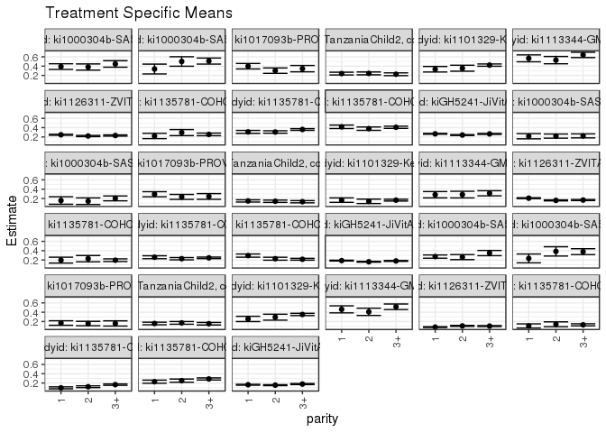

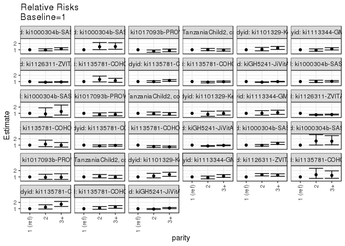

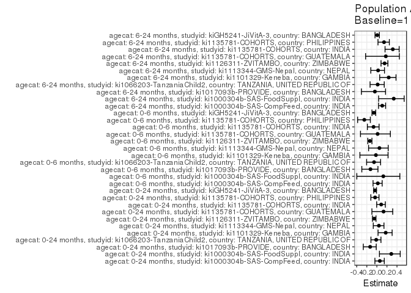

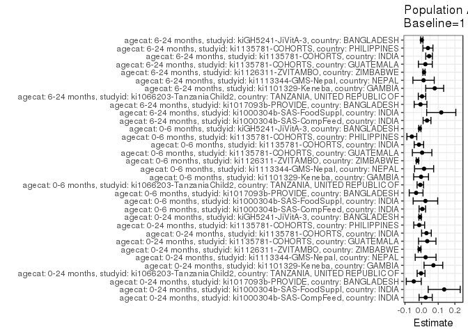

## Results Table

### Parameter: TSM

| agecat | studyid | country | intervention_level | baseline_level | estimate | ci_lower | ci_upper |
| --- | --- | --- | --- | --- | --- | --- | --- |
| 0-24 months | ki1000304b-SAS-CompFeed | INDIA | 1 | NA | 0.3906250 | 0.3307995 | 0.4504505 |
| 0-24 months | ki1000304b-SAS-CompFeed | INDIA | 2 | NA | 0.3813559 | 0.3153859 | 0.4473260 |
| 0-24 months | ki1000304b-SAS-CompFeed | INDIA | 3+ | NA | 0.4472574 | 0.3772779 | 0.5172369 |
| 0-24 months | ki1000304b-SAS-FoodSuppl | INDIA | 1 | NA | 0.3376623 | 0.2318999 | 0.4434248 |
| 0-24 months | ki1000304b-SAS-FoodSuppl | INDIA | 2 | NA | 0.5000000 | 0.3977009 | 0.6022991 |
| 0-24 months | ki1000304b-SAS-FoodSuppl | INDIA | 3+ | NA | 0.5087719 | 0.4437991 | 0.5737447 |
| 0-24 months | ki1017093b-PROVIDE | BANGLADESH | 1 | NA | 0.3985240 | 0.3401915 | 0.4568564 |
| 0-24 months | ki1017093b-PROVIDE | BANGLADESH | 2 | NA | 0.3032787 | 0.2455603 | 0.3609971 |
| 0-24 months | ki1017093b-PROVIDE | BANGLADESH | 3+ | NA | 0.3459459 | 0.2773523 | 0.4145395 |
| 0-24 months | ki1066203-TanzaniaChild2 | TANZANIA, UNITED REPUBLIC OF | 1 | NA | 0.2399513 | 0.2107333 | 0.2691693 |
| 0-24 months | ki1066203-TanzaniaChild2 | TANZANIA, UNITED REPUBLIC OF | 2 | NA | 0.2438392 | 0.2135232 | 0.2741552 |
| 0-24 months | ki1066203-TanzaniaChild2 | TANZANIA, UNITED REPUBLIC OF | 3+ | NA | 0.2261438 | 0.1964933 | 0.2557943 |
| 0-24 months | ki1101329-Keneba | GAMBIA | 1 | NA | 0.3333333 | 0.2736785 | 0.3929881 |
| 0-24 months | ki1101329-Keneba | GAMBIA | 2 | NA | 0.3551402 | 0.2910070 | 0.4192734 |
| 0-24 months | ki1101329-Keneba | GAMBIA | 3+ | NA | 0.4221498 | 0.3974358 | 0.4468639 |
| 0-24 months | ki1113344-GMS-Nepal | NEPAL | 1 | NA | 0.5672515 | 0.4929296 | 0.6415733 |
| 0-24 months | ki1113344-GMS-Nepal | NEPAL | 2 | NA | 0.5290323 | 0.4503857 | 0.6076789 |
| 0-24 months | ki1113344-GMS-Nepal | NEPAL | 3+ | NA | 0.6413043 | 0.5846739 | 0.6979348 |
| 0-24 months | ki1126311-ZVITAMBO | ZIMBABWE | 1 | NA | 0.2470431 | 0.2361325 | 0.2579538 |
| 0-24 months | ki1126311-ZVITAMBO | ZIMBABWE | 2 | NA | 0.2203593 | 0.2077860 | 0.2329326 |
| 0-24 months | ki1126311-ZVITAMBO | ZIMBABWE | 3+ | NA | 0.2311170 | 0.2176424 | 0.2445916 |
| 0-24 months | ki1135781-COHORTS | GUATEMALA | 1 | NA | 0.2211538 | 0.1647315 | 0.2775762 |
| 0-24 months | ki1135781-COHORTS | GUATEMALA | 2 | NA | 0.2941176 | 0.2287871 | 0.3594481 |
| 0-24 months | ki1135781-COHORTS | GUATEMALA | 3+ | NA | 0.2547569 | 0.2269804 | 0.2825333 |
| 0-24 months | ki1135781-COHORTS | INDIA | 1 | NA | 0.3086420 | 0.2768270 | 0.3404569 |
| 0-24 months | ki1135781-COHORTS | INDIA | 2 | NA | 0.3065878 | 0.2803219 | 0.3328537 |
| 0-24 months | ki1135781-COHORTS | INDIA | 3+ | NA | 0.3608365 | 0.3424805 | 0.3791925 |
| 0-24 months | ki1135781-COHORTS | PHILIPPINES | 1 | NA | 0.4180207 | 0.3808605 | 0.4551809 |
| 0-24 months | ki1135781-COHORTS | PHILIPPINES | 2 | NA | 0.3782991 | 0.3418962 | 0.4147020 |
| 0-24 months | ki1135781-COHORTS | PHILIPPINES | 3+ | NA | 0.4080664 | 0.3846029 | 0.4315299 |

[output cut: 69 more lines]

### Parameter: E(Y)

| agecat | studyid | country | intervention_level | baseline_level | estimate | ci_lower | ci_upper |
| --- | --- | --- | --- | --- | --- | --- | --- |
| 0-24 months | ki1000304b-SAS-CompFeed | INDIA | NA | NA | 0.4150694 | 0.3581204 | 0.4720184 |
| 0-24 months | ki1000304b-SAS-FoodSuppl | INDIA | NA | NA | 0.4735516 | 0.4243746 | 0.5227286 |
| 0-24 months | ki1017093b-PROVIDE | BANGLADESH | NA | NA | 0.3514286 | 0.3160364 | 0.3868207 |
| 0-24 months | ki1066203-TanzaniaChild2 | TANZANIA, UNITED REPUBLIC OF | NA | NA | 0.2367416 | 0.2195770 | 0.2539062 |
| 0-24 months | ki1101329-Keneba | GAMBIA | NA | NA | 0.4042232 | 0.3826511 | 0.4257953 |
| 0-24 months | ki1113344-GMS-Nepal | NEPAL | NA | NA | 0.5913621 | 0.5520608 | 0.6306634 |
| 0-24 months | ki1126311-ZVITAMBO | ZIMBABWE | NA | NA | 0.2347539 | 0.2277172 | 0.2417906 |
| 0-24 months | ki1135781-COHORTS | GUATEMALA | NA | NA | 0.2550336 | 0.2316956 | 0.2783715 |
| 0-24 months | ki1135781-COHORTS | INDIA | NA | NA | 0.3378028 | 0.3241691 | 0.3514364 |
| 0-24 months | ki1135781-COHORTS | PHILIPPINES | NA | NA | 0.4036125 | 0.3861835 | 0.4210415 |
| 0-24 months | kiGH5241-JiVitA-3 | BANGLADESH | NA | NA | 0.2581952 | 0.2517314 | 0.2646590 |
| 0-6 months | ki1000304b-SAS-CompFeed | INDIA | NA | NA | 0.2199336 | 0.1753445 | 0.2645227 |
| 0-6 months | ki1000304b-SAS-FoodSuppl | INDIA | NA | NA | 0.1788413 | 0.1410973 | 0.2165853 |
| 0-6 months | ki1017093b-PROVIDE | BANGLADESH | NA | NA | 0.2585714 | 0.2261125 | 0.2910304 |
| 0-6 months | ki1066203-TanzaniaChild2 | TANZANIA, UNITED REPUBLIC OF | NA | NA | 0.1395842 | 0.1255905 | 0.1535779 |
| 0-6 months | ki1101329-Keneba | GAMBIA | NA | NA | 0.1613611 | 0.1444653 | 0.1782570 |
| 0-6 months | ki1113344-GMS-Nepal | NEPAL | NA | NA | 0.2956811 | 0.2591967 | 0.3321655 |
| 0-6 months | ki1126311-ZVITAMBO | ZIMBABWE | NA | NA | 0.1810631 | 0.1746489 | 0.1874773 |
| 0-6 months | ki1135781-COHORTS | GUATEMALA | NA | NA | 0.2003763 | 0.1763021 | 0.2244505 |
| 0-6 months | ki1135781-COHORTS | INDIA | NA | NA | 0.2434743 | 0.2308547 | 0.2560940 |
| 0-6 months | ki1135781-COHORTS | PHILIPPINES | NA | NA | 0.2355453 | 0.2204685 | 0.2506222 |
| 0-6 months | kiGH5241-JiVitA-3 | BANGLADESH | NA | NA | 0.1762799 | 0.1706566 | 0.1819032 |
| 6-24 months | ki1000304b-SAS-CompFeed | INDIA | NA | NA | 0.3059755 | 0.2638053 | 0.3481458 |
| 6-24 months | ki1000304b-SAS-FoodSuppl | INDIA | NA | NA | 0.3518987 | 0.3047435 | 0.3990540 |
| 6-24 months | ki1017093b-PROVIDE | BANGLADESH | NA | NA | 0.1609756 | 0.1319065 | 0.1900447 |
| 6-24 months | ki1066203-TanzaniaChild2 | TANZANIA, UNITED REPUBLIC OF | NA | NA | 0.1600403 | 0.1439152 | 0.1761654 |
| 6-24 months | ki1101329-Keneba | GAMBIA | NA | NA | 0.3341996 | 0.3131165 | 0.3552826 |
| 6-24 months | ki1113344-GMS-Nepal | NEPAL | NA | NA | 0.4728814 | 0.4325613 | 0.5132014 |
| 6-24 months | ki1126311-ZVITAMBO | ZIMBABWE | NA | NA | 0.0939867 | 0.0884555 | 0.0995179 |
| 6-24 months | ki1135781-COHORTS | GUATEMALA | NA | NA | 0.1269580 | 0.1082147 | 0.1457012 |
| 6-24 months | ki1135781-COHORTS | INDIA | NA | NA | 0.1419682 | 0.1315821 | 0.1523542 |
| 6-24 months | ki1135781-COHORTS | PHILIPPINES | NA | NA | 0.2666429 | 0.2502871 | 0.2829988 |
| 6-24 months | kiGH5241-JiVitA-3 | BANGLADESH | NA | NA | 0.1639050 | 0.1577770 | 0.1700330 |

### Parameter: RR

| agecat | studyid | country | intervention_level | baseline_level | estimate | ci_lower | ci_upper |
| --- | --- | --- | --- | --- | --- | --- | --- |
| 0-24 months | ki1000304b-SAS-CompFeed | INDIA | 1 | 1 | 1.0000000 | 1.0000000 | 1.0000000 |
| 0-24 months | ki1000304b-SAS-CompFeed | INDIA | 2 | 1 | 0.9762712 | 0.8276984 | 1.1515129 |
| 0-24 months | ki1000304b-SAS-CompFeed | INDIA | 3+ | 1 | 1.1449789 | 0.9904415 | 1.3236285 |
| 0-24 months | ki1000304b-SAS-FoodSuppl | INDIA | 1 | 1 | 1.0000000 | 1.0000000 | 1.0000000 |
| 0-24 months | ki1000304b-SAS-FoodSuppl | INDIA | 2 | 1 | 1.4807692 | 1.0186113 | 2.1526146 |
| 0-24 months | ki1000304b-SAS-FoodSuppl | INDIA | 3+ | 1 | 1.5067476 | 1.0743335 | 2.1132064 |
| 0-24 months | ki1017093b-PROVIDE | BANGLADESH | 1 | 1 | 1.0000000 | 1.0000000 | 1.0000000 |
| 0-24 months | ki1017093b-PROVIDE | BANGLADESH | 2 | 1 | 0.7610049 | 0.5985725 | 0.9675159 |
| 0-24 months | ki1017093b-PROVIDE | BANGLADESH | 3+ | 1 | 0.8680681 | 0.6784546 | 1.1106744 |
| 0-24 months | ki1066203-TanzaniaChild2 | TANZANIA, UNITED REPUBLIC OF | 1 | 1 | 1.0000000 | 1.0000000 | 1.0000000 |
| 0-24 months | ki1066203-TanzaniaChild2 | TANZANIA, UNITED REPUBLIC OF | 2 | 1 | 1.0162028 | 0.8538912 | 1.2093674 |
| 0-24 months | ki1066203-TanzaniaChild2 | TANZANIA, UNITED REPUBLIC OF | 3+ | 1 | 0.9424571 | 0.7880450 | 1.1271253 |
| 0-24 months | ki1101329-Keneba | GAMBIA | 1 | 1 | 1.0000000 | 1.0000000 | 1.0000000 |
| 0-24 months | ki1101329-Keneba | GAMBIA | 2 | 1 | 1.0654206 | 0.8262373 | 1.3738437 |
| 0-24 months | ki1101329-Keneba | GAMBIA | 3+ | 1 | 1.2664495 | 1.0490876 | 1.5288470 |
| 0-24 months | ki1113344-GMS-Nepal | NEPAL | 1 | 1 | 1.0000000 | 1.0000000 | 1.0000000 |
| 0-24 months | ki1113344-GMS-Nepal | NEPAL | 2 | 1 | 0.9326239 | 0.7649755 | 1.1370133 |
| 0-24 months | ki1113344-GMS-Nepal | NEPAL | 3+ | 1 | 1.1305468 | 0.9653163 | 1.3240595 |
| 0-24 months | ki1126311-ZVITAMBO | ZIMBABWE | 1 | 1 | 1.0000000 | 1.0000000 | 1.0000000 |
| 0-24 months | ki1126311-ZVITAMBO | ZIMBABWE | 2 | 1 | 0.8919870 | 0.8298939 | 0.9587261 |
| 0-24 months | ki1126311-ZVITAMBO | ZIMBABWE | 3+ | 1 | 0.9355330 | 0.8695492 | 1.0065238 |
| 0-24 months | ki1135781-COHORTS | GUATEMALA | 1 | 1 | 1.0000000 | 1.0000000 | 1.0000000 |
| 0-24 months | ki1135781-COHORTS | GUATEMALA | 2 | 1 | 1.3299233 | 0.9482357 | 1.8652492 |
| 0-24 months | ki1135781-COHORTS | GUATEMALA | 3+ | 1 | 1.1519441 | 0.8728447 | 1.5202878 |
| 0-24 months | ki1135781-COHORTS | INDIA | 1 | 1 | 1.0000000 | 1.0000000 | 1.0000000 |
| 0-24 months | ki1135781-COHORTS | INDIA | 2 | 1 | 0.9933446 | 0.8687394 | 1.1358222 |
| 0-24 months | ki1135781-COHORTS | INDIA | 3+ | 1 | 1.1691103 | 1.0421578 | 1.3115277 |
| 0-24 months | ki1135781-COHORTS | PHILIPPINES | 1 | 1 | 1.0000000 | 1.0000000 | 1.0000000 |
| 0-24 months | ki1135781-COHORTS | PHILIPPINES | 2 | 1 | 0.9049770 | 0.7938583 | 1.0316494 |
| 0-24 months | ki1135781-COHORTS | PHILIPPINES | 3+ | 1 | 0.9761872 | 0.8781205 | 1.0852058 |

[output cut: 69 more lines]

### Parameter: PAR

| agecat | studyid | country | intervention_level | baseline_level | estimate | ci_lower | ci_upper |
| --- | --- | --- | --- | --- | --- | --- | --- |
| 0-24 months | ki1000304b-SAS-CompFeed | INDIA | 1 | NA | 0.0244444 | -0.0150202 | 0.0639090 |
| 0-24 months | ki1000304b-SAS-FoodSuppl | INDIA | 1 | NA | 0.1358893 | 0.0396342 | 0.2321444 |
| 0-24 months | ki1017093b-PROVIDE | BANGLADESH | 1 | NA | -0.0470954 | -0.0920469 | -0.0021439 |
| 0-24 months | ki1066203-TanzaniaChild2 | TANZANIA, UNITED REPUBLIC OF | 1 | NA | -0.0032097 | -0.0267382 | 0.0203189 |
| 0-24 months | ki1101329-Keneba | GAMBIA | 1 | NA | 0.0708899 | 0.0146294 | 0.1271504 |
| 0-24 months | ki1113344-GMS-Nepal | NEPAL | 1 | NA | 0.0241107 | -0.0385811 | 0.0868025 |
| 0-24 months | ki1126311-ZVITAMBO | ZIMBABWE | 1 | NA | -0.0122892 | -0.0204143 | -0.0041642 |
| 0-24 months | ki1135781-COHORTS | GUATEMALA | 1 | NA | 0.0338797 | -0.0184708 | 0.0862302 |
| 0-24 months | ki1135781-COHORTS | INDIA | 1 | NA | 0.0291608 | 0.0001186 | 0.0582030 |
| 0-24 months | ki1135781-COHORTS | PHILIPPINES | 1 | NA | -0.0144082 | -0.0471286 | 0.0183122 |
| 0-24 months | kiGH5241-JiVitA-3 | BANGLADESH | 1 | NA | -0.0092484 | -0.0164459 | -0.0020508 |
| 0-6 months | ki1000304b-SAS-CompFeed | INDIA | 1 | NA | 0.0042032 | -0.0153692 | 0.0237756 |
| 0-6 months | ki1000304b-SAS-FoodSuppl | INDIA | 1 | NA | 0.0229972 | -0.0508409 | 0.0968352 |
| 0-6 months | ki1017093b-PROVIDE | BANGLADESH | 1 | NA | -0.0329415 | -0.0743581 | 0.0084751 |
| 0-6 months | ki1066203-TanzaniaChild2 | TANZANIA, UNITED REPUBLIC OF | 1 | NA | -0.0077970 | -0.0271428 | 0.0115488 |
| 0-6 months | ki1101329-Keneba | GAMBIA | 1 | NA | -0.0031410 | -0.0477780 | 0.0414959 |
| 0-6 months | ki1113344-GMS-Nepal | NEPAL | 1 | NA | 0.0149793 | -0.0424085 | 0.0723671 |
| 0-6 months | ki1126311-ZVITAMBO | ZIMBABWE | 1 | NA | -0.0250463 | -0.0325195 | -0.0175731 |
| 0-6 months | ki1135781-COHORTS | GUATEMALA | 1 | NA | 0.0030079 | -0.0556511 | 0.0616668 |
| 0-6 months | ki1135781-COHORTS | INDIA | 1 | NA | -0.0160777 | -0.0443590 | 0.0122036 |
| 0-6 months | ki1135781-COHORTS | PHILIPPINES | 1 | NA | -0.0588334 | -0.0885596 | -0.0291072 |
| 0-6 months | kiGH5241-JiVitA-3 | BANGLADESH | 1 | NA | -0.0105103 | -0.0170078 | -0.0040128 |
| 6-24 months | ki1000304b-SAS-CompFeed | INDIA | 1 | NA | 0.0325942 | 0.0089271 | 0.0562613 |
| 6-24 months | ki1000304b-SAS-FoodSuppl | INDIA | 1 | NA | 0.1181325 | 0.0304420 | 0.2058230 |
| 6-24 months | ki1017093b-PROVIDE | BANGLADESH | 1 | NA | -0.0064253 | -0.0446808 | 0.0318303 |
| 6-24 months | ki1066203-TanzaniaChild2 | TANZANIA, UNITED REPUBLIC OF | 1 | NA | 0.0025365 | -0.0199242 | 0.0249973 |
| 6-24 months | ki1101329-Keneba | GAMBIA | 1 | NA | 0.0786930 | 0.0247924 | 0.1325935 |
| 6-24 months | ki1113344-GMS-Nepal | NEPAL | 1 | NA | 0.0118035 | -0.0523058 | 0.0759129 |
| 6-24 months | ki1126311-ZVITAMBO | ZIMBABWE | 1 | NA | 0.0144310 | 0.0079704 | 0.0208915 |
| 6-24 months | ki1135781-COHORTS | GUATEMALA | 1 | NA | 0.0225624 | -0.0190753 | 0.0642000 |
| 6-24 months | ki1135781-COHORTS | INDIA | 1 | NA | 0.0450226 | 0.0250340 | 0.0650113 |
| 6-24 months | ki1135781-COHORTS | PHILIPPINES | 1 | NA | 0.0380245 | 0.0080308 | 0.0680182 |
| 6-24 months | kiGH5241-JiVitA-3 | BANGLADESH | 1 | NA | 0.0012165 | -0.0058665 | 0.0082995 |

### Parameter: PAF

| agecat | studyid | country | intervention_level | baseline_level | estimate | ci_lower | ci_upper |
| --- | --- | --- | --- | --- | --- | --- | --- |
| 0-24 months | ki1000304b-SAS-CompFeed | INDIA | 1 | NA | 0.0588923 | -0.0390883 | 0.1476339 |
| 0-24 months | ki1000304b-SAS-FoodSuppl | INDIA | 1 | NA | 0.2869577 | 0.0509431 | 0.4642795 |
| 0-24 months | ki1017093b-PROVIDE | BANGLADESH | 1 | NA | -0.1340113 | -0.2695973 | -0.0129052 |
| 0-24 months | ki1066203-TanzaniaChild2 | TANZANIA, UNITED REPUBLIC OF | 1 | NA | -0.0135576 | -0.1179764 | 0.0811085 |
| 0-24 months | ki1101329-Keneba | GAMBIA | 1 | NA | 0.1753731 | 0.0237118 | 0.3034746 |
| 0-24 months | ki1113344-GMS-Nepal | NEPAL | 1 | NA | 0.0407714 | -0.0713899 | 0.1411908 |
| 0-24 months | ki1126311-ZVITAMBO | ZIMBABWE | 1 | NA | -0.0523494 | -0.0875228 | -0.0183137 |
| 0-24 months | ki1135781-COHORTS | GUATEMALA | 1 | NA | 0.1328441 | -0.0985709 | 0.3155114 |
| 0-24 months | ki1135781-COHORTS | INDIA | 1 | NA | 0.0863249 | -0.0038186 | 0.1683735 |
| 0-24 months | ki1135781-COHORTS | PHILIPPINES | 1 | NA | -0.0356981 | -0.1200305 | 0.0422845 |
| 0-24 months | kiGH5241-JiVitA-3 | BANGLADESH | 1 | NA | -0.0358194 | -0.0640503 | -0.0083374 |
| 0-6 months | ki1000304b-SAS-CompFeed | INDIA | 1 | NA | 0.0191113 | -0.0757596 | 0.1056156 |
| 0-6 months | ki1000304b-SAS-FoodSuppl | INDIA | 1 | NA | 0.1285897 | -0.3986622 | 0.4570842 |
| 0-6 months | ki1017093b-PROVIDE | BANGLADESH | 1 | NA | -0.1273980 | -0.2993131 | 0.0217706 |
| 0-6 months | ki1066203-TanzaniaChild2 | TANZANIA, UNITED REPUBLIC OF | 1 | NA | -0.0558589 | -0.2038776 | 0.0739606 |
| 0-6 months | ki1101329-Keneba | GAMBIA | 1 | NA | -0.0194658 | -0.3372562 | 0.2228037 |
| 0-6 months | ki1113344-GMS-Nepal | NEPAL | 1 | NA | 0.0506604 | -0.1646653 | 0.2261762 |
| 0-6 months | ki1126311-ZVITAMBO | ZIMBABWE | 1 | NA | -0.1383292 | -0.1802105 | -0.0979341 |
| 0-6 months | ki1135781-COHORTS | GUATEMALA | 1 | NA | 0.0150111 | -0.3258814 | 0.2682580 |
| 0-6 months | ki1135781-COHORTS | INDIA | 1 | NA | -0.0660345 | -0.1887387 | 0.0440040 |
| 0-6 months | ki1135781-COHORTS | PHILIPPINES | 1 | NA | -0.2497751 | -0.3823109 | -0.1299469 |
| 0-6 months | kiGH5241-JiVitA-3 | BANGLADESH | 1 | NA | -0.0596228 | -0.0971120 | -0.0234146 |
| 6-24 months | ki1000304b-SAS-CompFeed | INDIA | 1 | NA | 0.1065256 | 0.0335461 | 0.1739942 |
| 6-24 months | ki1000304b-SAS-FoodSuppl | INDIA | 1 | NA | 0.3357003 | 0.0349818 | 0.5427090 |
| 6-24 months | ki1017093b-PROVIDE | BANGLADESH | 1 | NA | -0.0399146 | -0.3068267 | 0.1724822 |
| 6-24 months | ki1066203-TanzaniaChild2 | TANZANIA, UNITED REPUBLIC OF | 1 | NA | 0.0158494 | -0.1349883 | 0.1466411 |
| 6-24 months | ki1101329-Keneba | GAMBIA | 1 | NA | 0.2354670 | 0.0561072 | 0.3807446 |
| 6-24 months | ki1113344-GMS-Nepal | NEPAL | 1 | NA | 0.0249608 | -0.1205028 | 0.1515404 |
| 6-24 months | ki1126311-ZVITAMBO | ZIMBABWE | 1 | NA | 0.1535426 | 0.0824678 | 0.2191117 |
| 6-24 months | ki1135781-COHORTS | GUATEMALA | 1 | NA | 0.1777151 | -0.2240976 | 0.4476320 |
| 6-24 months | ki1135781-COHORTS | INDIA | 1 | NA | 0.3171319 | 0.1625951 | 0.4431501 |
| 6-24 months | ki1135781-COHORTS | PHILIPPINES | 1 | NA | 0.1426046 | 0.0225519 | 0.2479121 |
| 6-24 months | kiGH5241-JiVitA-3 | BANGLADESH | 1 | NA | 0.0074220 | -0.0367611 | 0.0497221 |